# Diagnostic Report – 201910gavi-5

JHU-Lee

2021-08-06 16:58:31

## The Model Specs

Specific characteristics of this model are shown in this table.

| Item | Details |
| --- | --- |
| Disease | Cholera |
| ModelingGroup | JHU-Lee |
| YearRange | 2000-2100 |
| AgeRange | 0-100 |
| CountryList | COD ETH KEN SOM SSD |
| SimulatedOutcomes | cohort_size cases deaths dalys |

## Coverage Trajectories

The trends of the specific coverage sets for the campaign scenario can be observed in this figure.

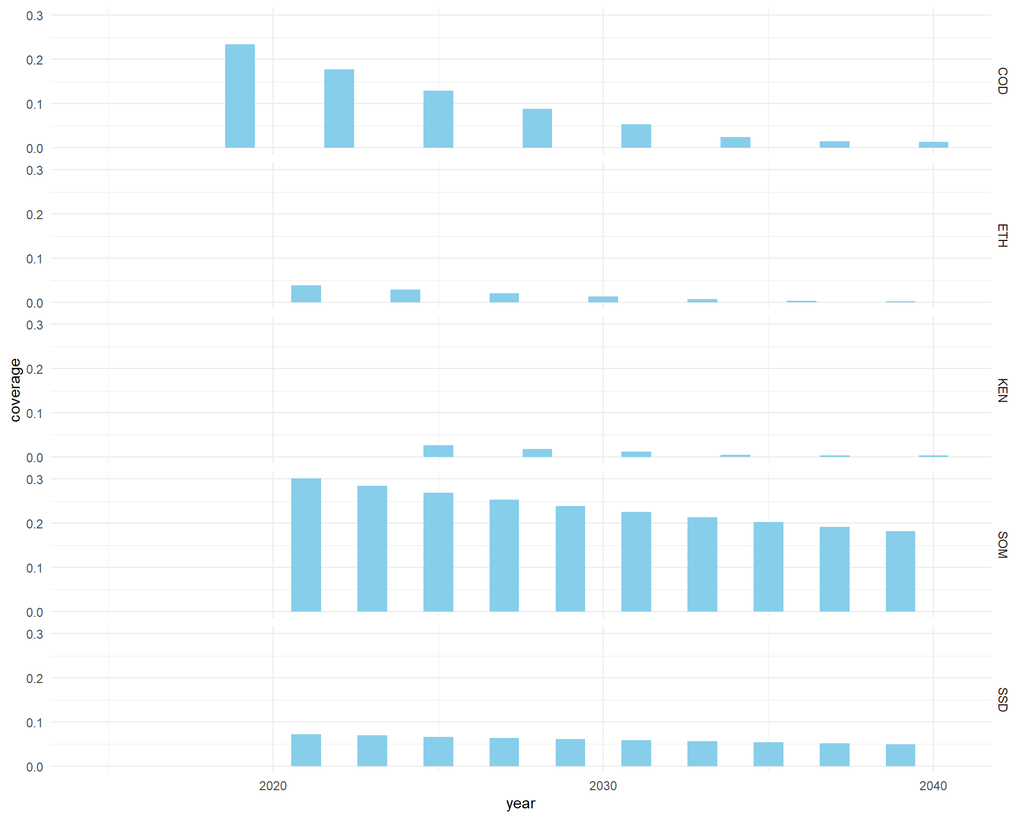

Age ranges of the different coverage sets include either standard age ranges (as it is the case of Measles) but sometimes it differs by year and country so that several combinations can be possible (See table below).

| coverage_set_name | age_from | age_to | freq |
| --- | --- | --- | --- |
| cholera-campaign-default-test | 1 | 100 | 130 |

## Fully vaccinated persons (FVPs)

The estimates of fully vaccinated persons (FVPs) are obtained by multiplying coverage from each coverage set and the target population. The following picture shows the Fully Vaccinated Persons (FVPs) at global level by scenario for Cholera.

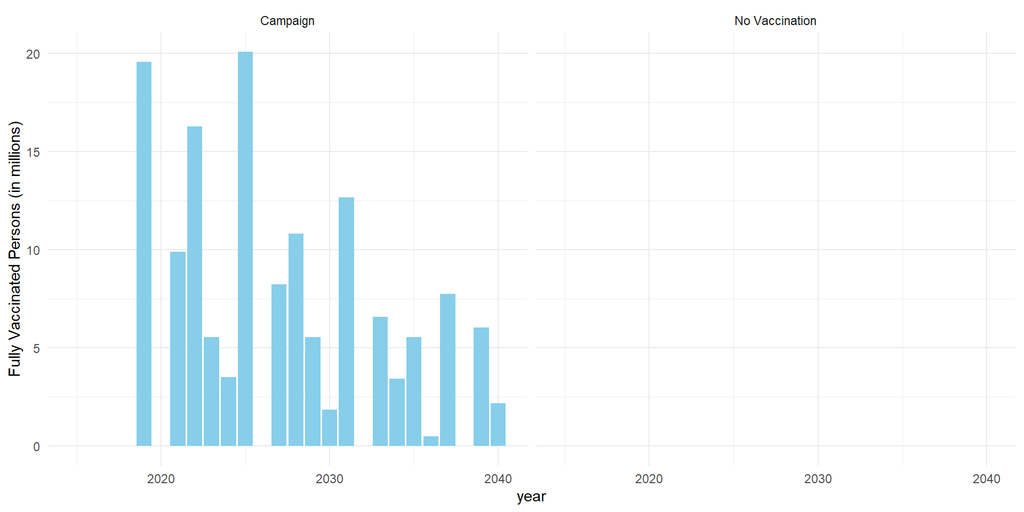

## Check the general info

Expected number of rows.

| scenario_description | outcome_code | number_of_non_na_rows |
| --- | --- | --- |
| Campaign, Default | cohort_size | 51005 |
| Campaign, Default | cases | 51005 |
| Campaign, Default | deaths | 51005 |
| Campaign, Default | dalys | 51005 |
| No vaccination | cohort_size | 51005 |
| No vaccination | cases | 51005 |
| No vaccination | deaths | 51005 |
| No vaccination | dalys | 51005 |

This figure shows the shape of the upload by scenarios and outcomes (whether there are missing values)

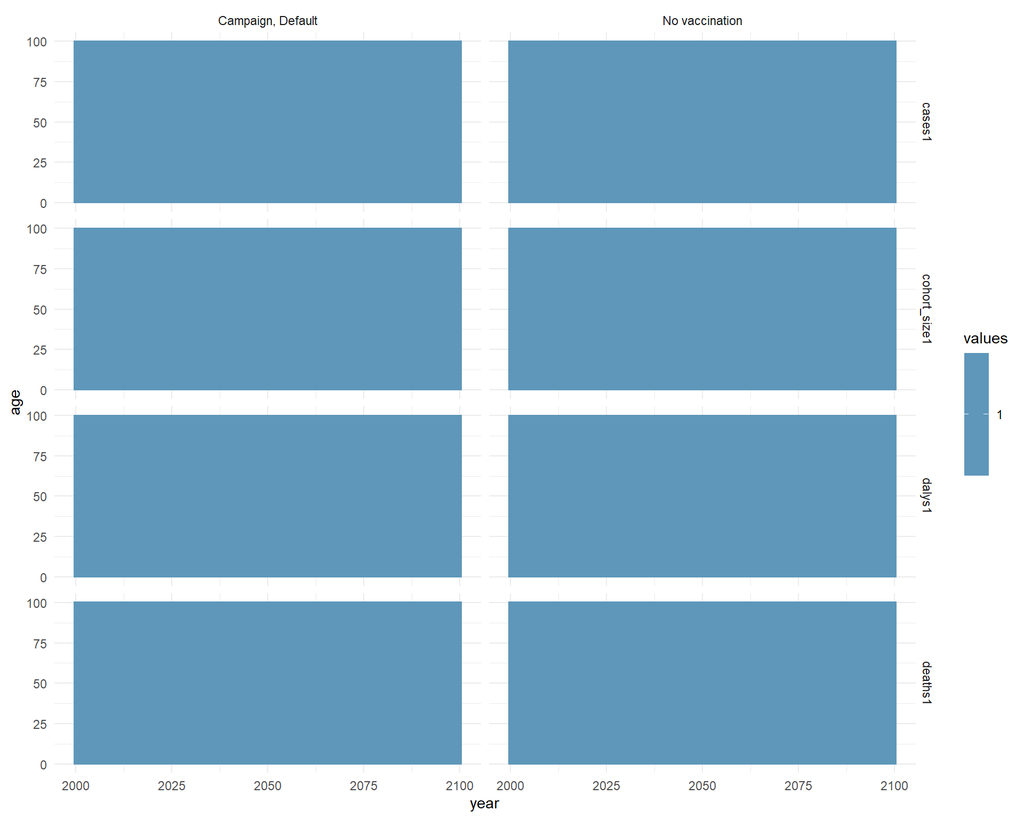

This figure shows the pattern of positive values (number of positive values across all five countries)

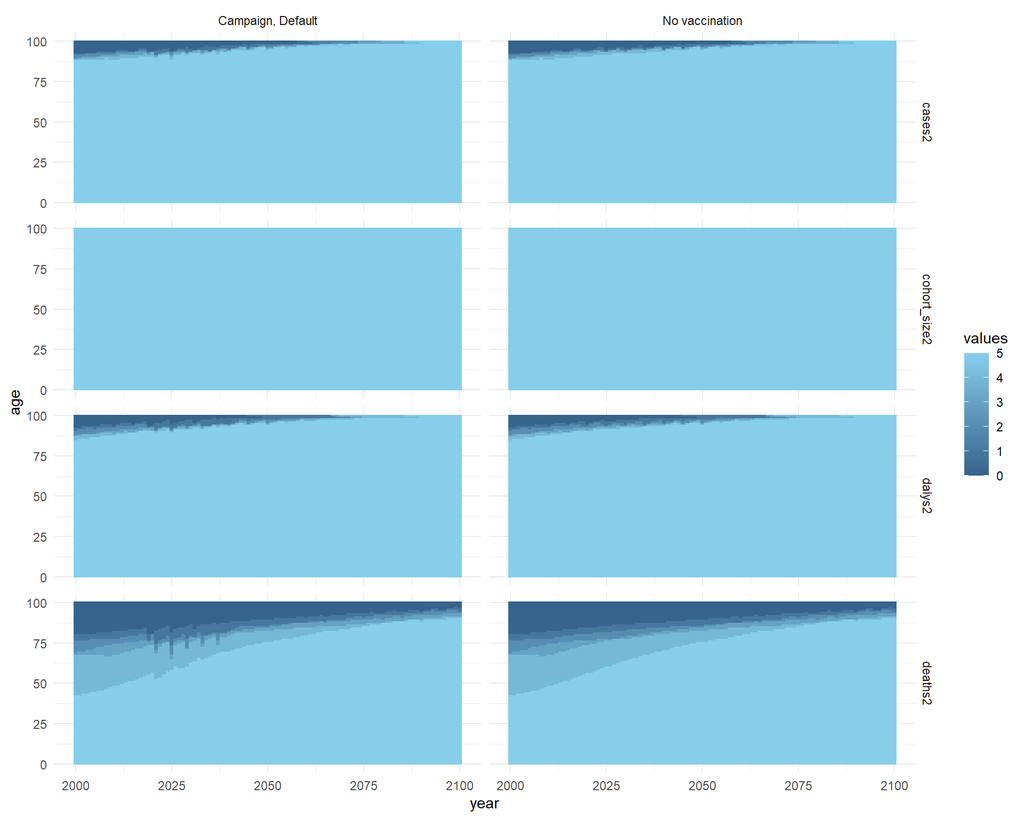

## Check the cohort size

### Notion: the interpolated population dataset doesn’t have info for age 100, we will leave that out to keep the consistency.

This figure shows the comparison of cohort size against interpolated population in all countries.

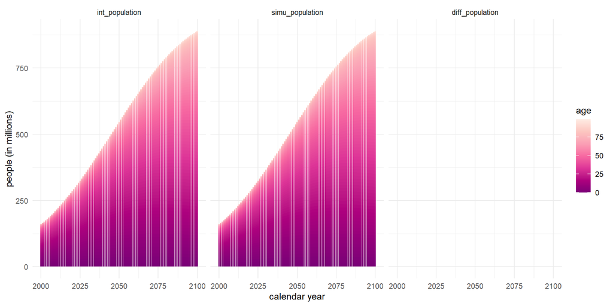

This figure shows the comparison of cohort size against interpolated population in the five countries.

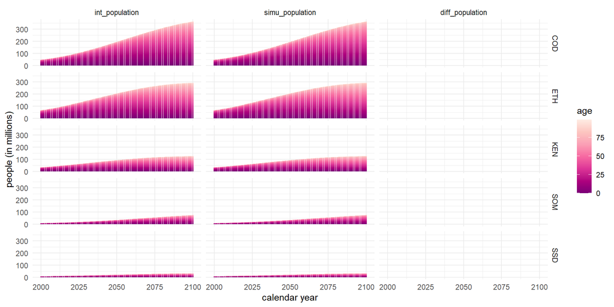

These two tables provide us with more insights into the difference between interpolated population and cohort size.

| Countries | PopulationDifference | Frequency | Proportion |
| --- | --- | --- | --- |
| All | 0 | 10100 | 1 |

| country | Countries | PopulationDifference | Frequency | Proportion |
| --- | --- | --- | --- | --- |
| COD | COD | 0 | 10100 | 1 |
| ETH | ETH | 0 | 10100 | 1 |
| KEN | KEN | 0 | 10100 | 1 |
| SOM | SOM | 0 | 10100 | 1 |
| SSD | SSD | 0 | 10100 | 1 |

## Checking patterns of the specific estimates

This figure shows the aggregated (for all countries) age distribution patterns by outcome.

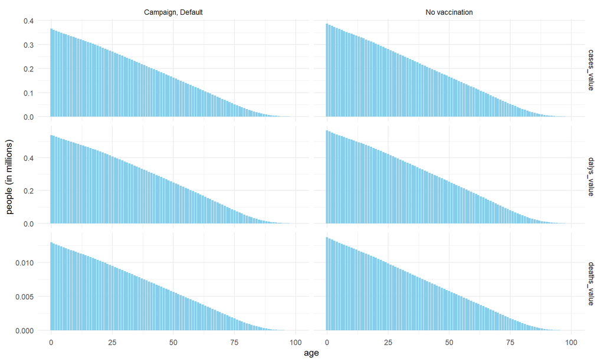

This figure shows the global burden values by decades 2000-2030.

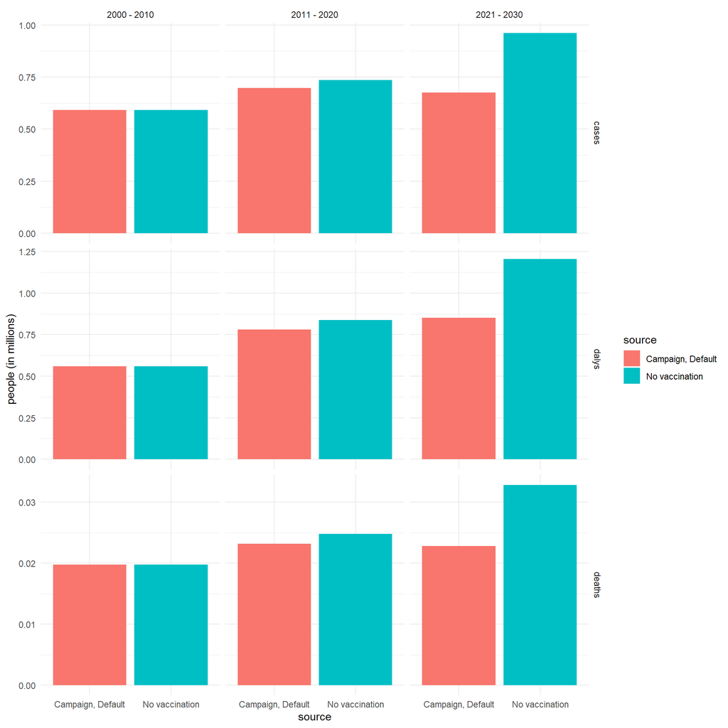

This figure shows the global burden disease values 2000-2100.

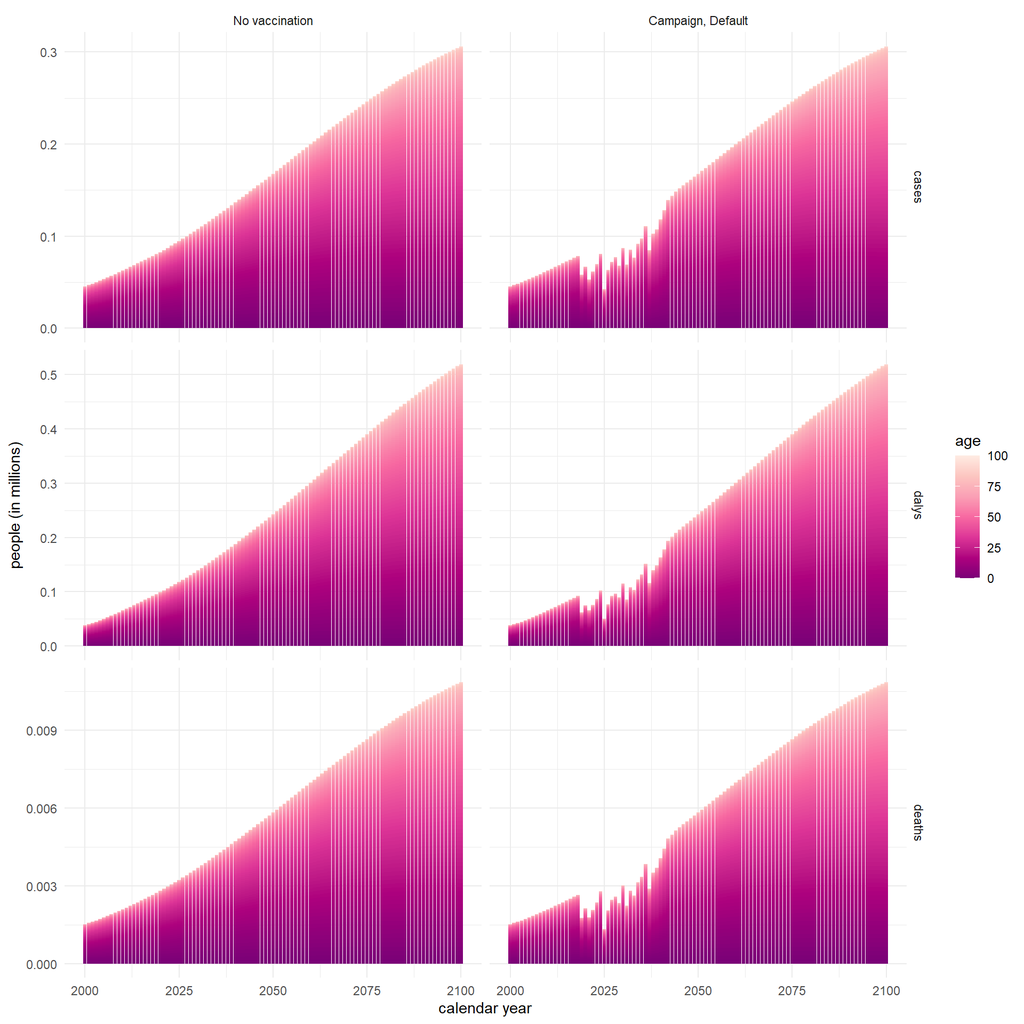